[figure not shown]

## Bringing together marine biodiversity, environmental and maritime boundaries data in R

Salvador Fernandez Laura Marquez

May 30th 2022

[figure not shown]

## Proper collection allow humans and machines to find the data

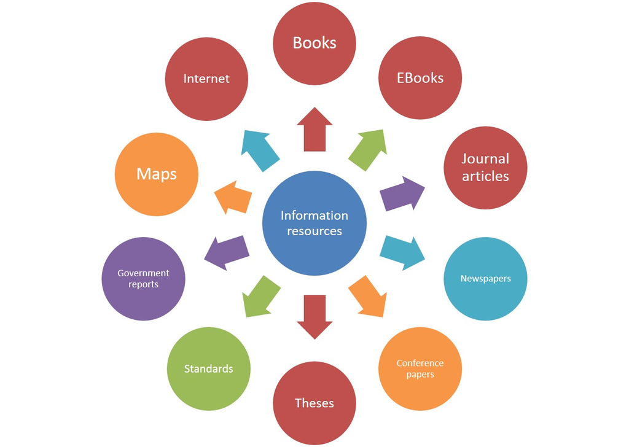

## Reusing data leads to discovery, innovation & scientific integration

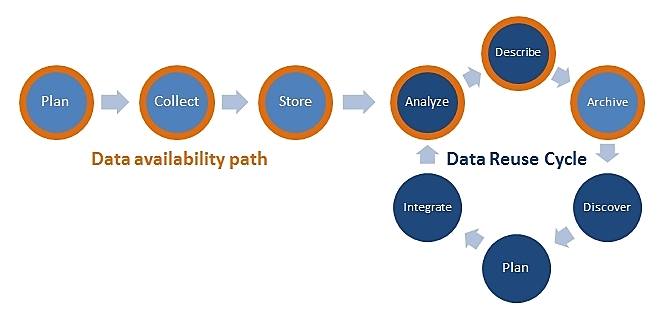

## FAIR principles

[figure not shown]

## We will learn

1. How to access, query and obtain the data
2. Visualize and get them ready for further exploration and analyses
3. To use R packages: lwdataexplorer, eurobis, worrms, mregions, sdmpredictors

## 1. Access marine regions data

The Marine Regions Gazetteer is a standard list of marine georeferenced place names.

> Gazetteer: a dictionary of geographical names.

https://www.thefreedictionary.com/gazetteer

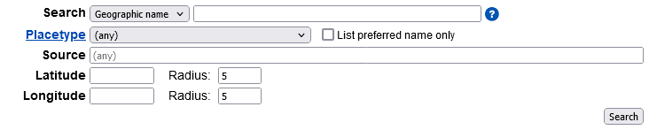

## Gazetteer

Every record has an unique identifier: MRGID

## Gazetteer

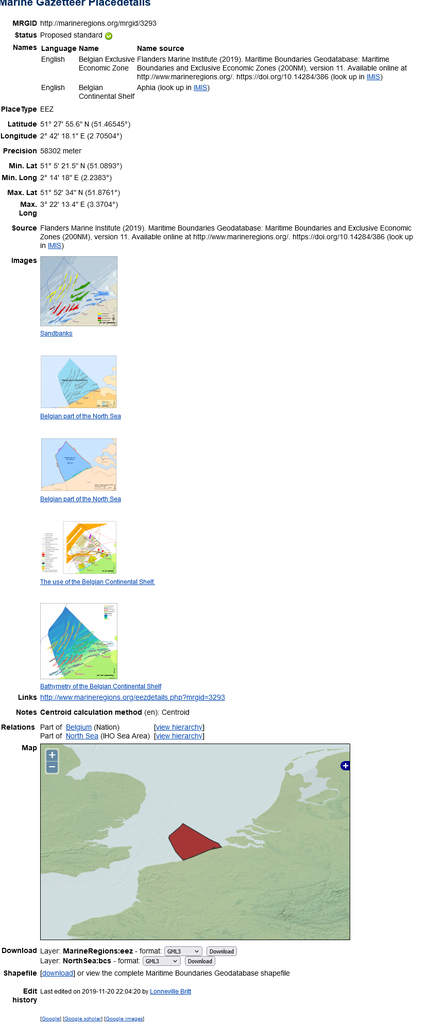

## mregions2

The `mregions2` R package can download the Gazetteer record into R. Just pass the MRGID:

```
## Simple feature collection with 1 feature and 14 fields
## geometry type:  MULTIPOLYGON
## dimension:      XY
## bbox:           xmin: -4.445371 ymin: 50.99536 xmax: 12.00594 ymax: 61.01702
## geographic CRS: WGS 84
```